# Lab1

RawanGalal

2/11/2021

```r
library(tidyverse)
data = read_csv("LAB 1 - Online Retail Data.csv")
data
```

```
## # A tibble: 286,360 x 12
##    InvoiceNo StockCode Description Quantity InvoiceDate UnitPrice CustomerID
##    <chr>     <chr>     <chr>          <dbl> <chr>           <dbl>      <dbl>
##  1 C556445   M         Manual            -1 6/10/2011      38970       15098
##  2 C540118   AMAZONFEE AMAZON FEE        -1 1/5/2011       16454.         NA
##  3 537632    AMAZONFEE AMAZON FEE         1 12/7/2010      13541.         NA
##  4 C537651   AMAZONFEE AMAZON FEE        -1 12/7/2010      13541.         NA
##  5 C537644   AMAZONFEE AMAZON FEE        -1 12/7/2010      13475.         NA
##  6 C580604   AMAZONFEE AMAZON FEE        -1 12/5/2011      11586.         NA
##  7 C553355   AMAZONFEE AMAZON FEE        -1 5/16/2011       7007.         NA
##  8 C551699   M         Manual            -1 5/3/2011        6930       16029
##  9 C537652   AMAZONFEE AMAZON FEE        -1 12/7/2010       6707.         NA
## 10 C564341   AMAZONFEE AMAZON FEE        -1 8/24/2011       6663.         NA
## # ... with 286,350 more rows, and 5 more variables: Country <chr>,
## #   Canceled <dbl>, Revenue <dbl>, Category <dbl>, Destination <chr>
```

# 1. Data validation

## Level 1 –Cells, records, file

```r
summary(data)
```

```
##   InvoiceNo          StockCode         Description           Quantity
##  Length:286360      Length:286360      Length:286360      Min.   :-9600.00
##  Class :character   Class :character   Class :character   1st Qu.:    1.00
##  Mode  :character   Mode  :character   Mode  :character   Median :    3.00
##                                                           Mean   :    9.86
##                                                           3rd Qu.:   10.00
##                                                           Max.   :80995.00
##
##  InvoiceDate          UnitPrice            CustomerID      Country
##  Length:286360      Min.   :-110620600   Min.   :12347   Length:286360
##  Class :character   1st Qu.:         1   1st Qu.:13953   Class :character
##  Mode  :character   Median :         2   Median :15159   Mode  :character
##                     Mean   :      -396   Mean   :15289
##                     3rd Qu.:         4   3rd Qu.:16791
##                     Max.   :     38970   Max.   :18287
##                     NA's   :10190        NA's   :74844
##     Canceled          Revenue             Category     Destination
##  Min.   :0.00000   Min.   :-11062.06   Min.   :1.000   Length:286360
##  1st Qu.:0.00000   1st Qu.:     3.75   1st Qu.:2.000   Class :character
##  Median :0.00000   Median :     9.87   Median :3.000   Mode  :character
##  Mean   :0.01973   Mean   :    19.83   Mean   :2.781
##  3rd Qu.:0.00000   3rd Qu.:    17.40   3rd Qu.:4.000
##  Max.   :2.00000   Max.   :168469.60   Max.   :5.000
##                                        NA's   :1384
```

# 2. DATA CLEANSING

## Handling negative values and NA’s in UnitPrice:

### I decided to drop these values. If the percentage was higher, I would fill it with the average of the unit price, per stockcode.

```r
data %>%
  filter(UnitPrice > 0) -> data
data
```

```
## # A tibble: 274,786 x 12
##    InvoiceNo StockCode Description Quantity InvoiceDate UnitPrice CustomerID
##    <chr>     <chr>     <chr>          <dbl> <chr>           <dbl>      <dbl>
##  1 C556445   M         Manual            -1 6/10/2011      38970       15098
##  2 C540118   AMAZONFEE AMAZON FEE        -1 1/5/2011       16454.         NA
##  3 537632    AMAZONFEE AMAZON FEE         1 12/7/2010      13541.         NA
##  4 C537651   AMAZONFEE AMAZON FEE        -1 12/7/2010      13541.         NA
##  5 C537644   AMAZONFEE AMAZON FEE        -1 12/7/2010      13475.         NA
##  6 C580604   AMAZONFEE AMAZON FEE        -1 12/5/2011      11586.         NA
##  7 C553355   AMAZONFEE AMAZON FEE        -1 5/16/2011       7007.         NA
##  8 C551699   M         Manual            -1 5/3/2011        6930       16029
##  9 C537652   AMAZONFEE AMAZON FEE        -1 12/7/2010       6707.         NA
## 10 C564341   AMAZONFEE AMAZON FEE        -1 8/24/2011       6663.         NA
## # ... with 274,776 more rows, and 5 more variables: Country <chr>,
## #   Canceled <dbl>, Revenue <dbl>, Category <dbl>, Destination <chr>
```

```r
###droped negative rows(11, 574)
```

## Remove duplicate rows

```r
data %>% distinct() %>% arrange(InvoiceNo) -> data
#unique(data)
```

```r
summary(data)
```

```
##   InvoiceNo          StockCode         Description           Quantity
##  Length:265882      Length:265882      Length:265882      Min.   :-1515.00
##  Class :character   Class :character   Class :character   1st Qu.:    1.00
##  Mode  :character   Mode  :character   Mode  :character   Median :    3.00
##                                                           Mean   :   10.13
##                                                           3rd Qu.:   10.00
##                                                           Max.   :80995.00
##
##  InvoiceDate          UnitPrice          CustomerID      Country
##  Length:265882      Min.   :    0.00   Min.   :12347   Length:265882
##  Class :character   1st Qu.:    1.25   1st Qu.:13951   Class :character
##  Mode  :character   Median :    2.10   Median :15150   Mode  :character
##                     Mean   :    4.83   Mean   :15284
##                     3rd Qu.:    4.13   3rd Qu.:16782
##                     Max.   :38970.00   Max.   :18287
##                                        NA's   :68178
##     Canceled          Revenue             Category     Destination
##  Min.   :0.00000   Min.   :     0.00   Min.   :1.000   Length:265882
##  1st Qu.:0.00000   1st Qu.:     3.75   1st Qu.:2.000   Class :character
##  Median :0.00000   Median :     9.87   Median :3.000   Mode  :character
##  Mean   :0.02019   Mean   :    19.75   Mean   :2.775
##  3rd Qu.:0.00000   3rd Qu.:    17.70   3rd Qu.:4.000
##  Max.   :2.00000   Max.   :168469.60   Max.   :5.000
##
```

## IQR for UnitPrice is 3

```r
#data %>%
 # filter(!is.na(UnitPrice)) -> data
  #hist(to_integer(data["UnitPrice"]))

### mutate(across(is.numeric, ~ replace_na(., 0) ))
```

```r
count(data["UnitPrice"])
```

```
## # A tibble: 1 x 1
##        n
##    <int>
## 1 265882
```

### null values successfully removed!

## Detecting outliers

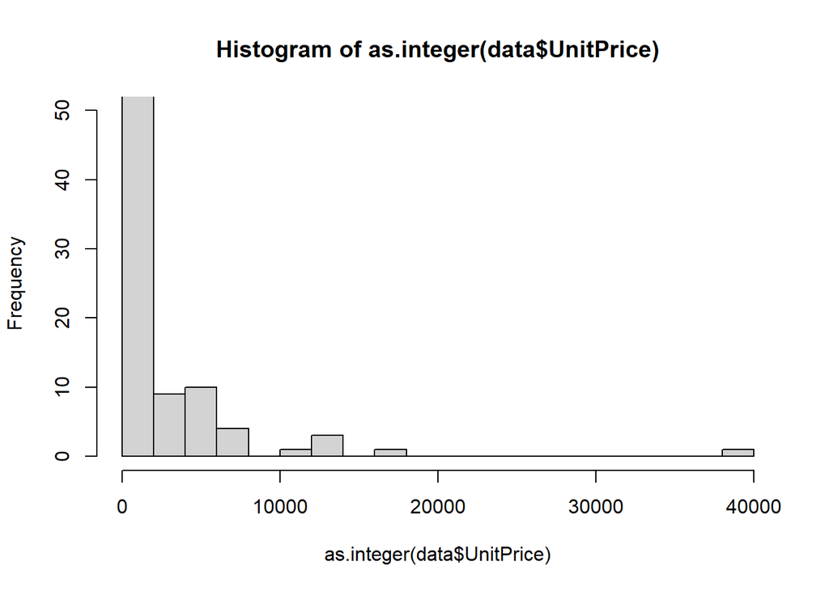

```r
  hist( as.integer(data$UnitPrice), xlim=c(0,40000), breaks=20, ylim=c(0,50))
```

### As the histogram illustrates, there’s 1 observation that is considered an outlier: the maximum UnitPrice = 38970.

```r
data %>% arrange(desc(UnitPrice))
```

```
## # A tibble: 265,882 x 12
##    InvoiceNo StockCode Description Quantity InvoiceDate UnitPrice CustomerID
##    <chr>     <chr>     <chr>          <dbl> <chr>           <dbl>      <dbl>
##  1 C556445   M         Manual            -1 6/10/2011      38970       15098
##  2 C540118   AMAZONFEE AMAZON FEE        -1 1/5/2011       16454.         NA
##  3 537632    AMAZONFEE AMAZON FEE         1 12/7/2010      13541.         NA
##  4 C537651   AMAZONFEE AMAZON FEE        -1 12/7/2010      13541.         NA
##  5 C537644   AMAZONFEE AMAZON FEE        -1 12/7/2010      13475.         NA
##  6 C580604   AMAZONFEE AMAZON FEE        -1 12/5/2011      11586.         NA
##  7 C553355   AMAZONFEE AMAZON FEE        -1 5/16/2011       7007.         NA
##  8 C551699   M         Manual            -1 5/3/2011        6930       16029
##  9 C537652   AMAZONFEE AMAZON FEE        -1 12/7/2010       6707.         NA
## 10 C564341   AMAZONFEE AMAZON FEE        -1 8/24/2011       6663.         NA
## # ... with 265,872 more rows, and 5 more variables: Country <chr>,
## #   Canceled <dbl>, Revenue <dbl>, Category <dbl>, Destination <chr>
```

### After further investigation in the data, it turns out that this extreme price corresponds to customer number 15098. This customer performed another transaction with a total price of 297. This is interesting! It shows an unusual behavior for the customer. It could indicate a fraud. So I decided to keep this extreme point.

### Now, we’re ready to answer Q1.

```r
##data %>%
  ##group_by(StockCode)-> grouped_data

##grouped_data%>%
  ##summarise( avg_price = mean(UnitPrice),
    ##          UnitPrice= UnitPrice,
      ##       UnitPrice_ = replace_na(UnitPrice, avg_price))-> data_
```

## Q1. What is the average price for items shipped international Vs Domestic?

```r
data %>%
  group_by(Destination) %>%
  summarize(avg_price = mean(UnitPrice * Quantity))
```

```
## # A tibble: 2 x 2
##   Destination   avg_price
## * <chr>             <dbl>
## 1 Domestic           17.1
## 2 International      33.0
```

### clearly, items shipped internationally contribute more to our revenue. This might open doors for methods to sustain international customers, or increase the rate of purchase for domestic ones.

## Q2: What is the most sold product category?

## Detecting outliers in the Quantity column

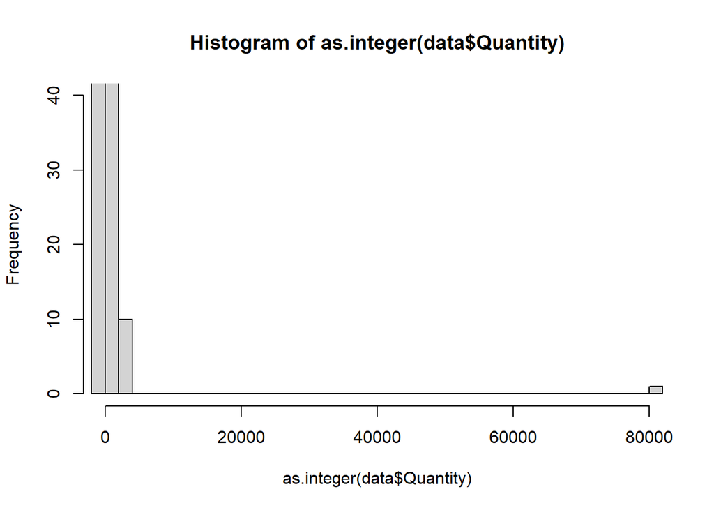

```r
  hist( as.integer(data$Quantity), xlim=c(0,80000), breaks=30, ylim=c(0,40))
```

### clearly, there’s one extreme point (the Max. Quantity, which equals 80995.00). This point corresponds to a **paper craft, little birdie** product. Again, interesting. Could indicate a fraud, (For a theif throwing a party perhabs!) since that customer only has another transaction where he bought 1 pantry scrubbing brush. or perhaps the customer just started his crafts business! In either cases, This point is too important to exclude from the analysis!

```r
data %>%
  group_by(StockCode) %>%
  mutate(quantity_sold = if_else(Quantity>0, Quantity, 0)) %>%
  summarise(quantity_per_cat = sum(quantity_sold)) %>%
 arrange(desc(quantity_per_cat))
```

```
## # A tibble: 3,823 x 2
##    StockCode quantity_per_cat
##    <chr>                <dbl>
##  1 23843                80995
##  2 84077                28590
##  3 22197                23402
##  4 85099B               22925
##  5 84879                20247
##  6 21212                19133
##  7 22492                15973
##  8 85123A               14486
##  9 23084                14279
## 10 21977                12917
## # ... with 3,813 more rows
```

```r
# sort / take the maximum
```

## - Answer: the most sold product category is *23843* which we sold 80995 items from it between 01/12/2010 and 09/12/2011

## Q3: What is the most profitable product category?

### The Revenue column doesn’t contain any null values.

```r
data %>%
  group_by(StockCode) %>%
  summarize(revenue_per_category = sum(Revenue)) %>%
  arrange(desc(revenue_per_category))
```

```
## # A tibble: 3,823 x 2
##    StockCode revenue_per_category
##    <chr>                    <dbl>
##  1 23843                  168470.
##  2 DOT                    113209.
##  3 22423                   95260.
##  4 47566                   45747.
##  5 85099B                  44726.
##  6 85123A                  41774.
##  7 POST                    37349.
##  8 84879                   32363.
##  9 23084                   31028.
## 10 21137                   28731.
## # ... with 3,813 more rows
```

## - Answer: the most profitable product category is *23843*. This category alone increases our revenue by *168469.60*

## (Technically, Profit = revenue - cost. But since the information of cost isn’t available, I used the revenue column only.)

## Q4: 4. Which country has the highest cancellation rates .. is it really concerning?

## Detecting outliers for the canceled column.

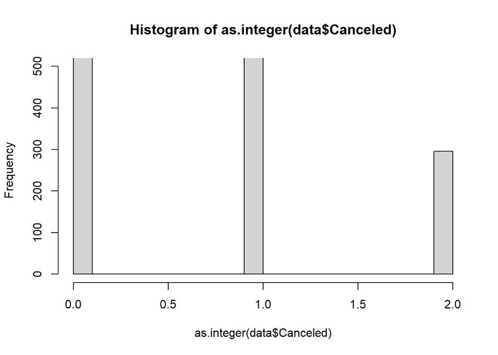

```r
  hist( as.integer(data$Canceled), xlim=c(0,2), breaks=20, ylim=c(0,500))
```

### No outliers!

```r
##group by country
data %>%
  group_by(Country) %>%
  summarize(total_cancellation = sum(Canceled),
            quantity_sold = sum(Quantity)) %>%
  arrange(desc(total_cancellation))
```

```
## # A tibble: 40 x 3
##    Country        total_cancellation quantity_sold
##    <chr>                       <dbl>         <dbl>
##  1 United Kingdom               4408       2128334
##  2 Germany                       262         57665
##  3 UK                            179        110224
##  4 EIRE                          164         67782
##  5 France                         78         53965
##  6 USA                            52           333
##  7 Australia                      37         40514
##  8 Spain                          31         12658
##  9 Italy                          19          4227
## 10 Japan                          19         13744
## # ... with 30 more rows
```

## On the other hand, US has a cancellation/sold ration of 0.2. This raises questions and could require further investigation.